# Loan Prediction - R Notebook

#Problem Statement : Is the customer potential customer for personal loan in future?

```r
setwd("C:/Users/nupur/Desktop/DataMining")

#Reading data
library(readxl)
bankData<-read_excel("Thera Bank-Data Set.xlsx",2)
```

#Understanding data Structure

```r
dim(bankData) #5000 rows and 14 columns
```

```
## [1] 5000   14
```

```r
str(bankData)
```

```
## tibble [5,000 × 14] (S3: tbl_df/tbl/data.frame)
##  $ ID                   : num [1:5000] 1 2 3 4 5 6 7 8 9 10 ...
##  $ Age (in years)       : num [1:5000] 25 45 39 35 35 37 53 50 35 34 ...
##  $ Experience (in years): num [1:5000] 1 19 15 9 8 13 27 24 10 9 ...
##  $ Income (in K/month)  : num [1:5000] 49 34 11 100 45 29 72 22 81 180 ...
##  $ ZIP Code             : num [1:5000] 91107 90089 94720 94112 91330 ...
##  $ Family members       : num [1:5000] 4 3 1 1 4 4 2 1 3 1 ...
##  $ CCAvg                : num [1:5000] 1.6 1.5 1 2.7 1 0.4 1.5 0.3 0.6 8.9 ...
##  $ Education            : num [1:5000] 1 1 1 2 2 2 2 3 2 3 ...
##  $ Mortgage             : num [1:5000] 0 0 0 0 0 155 0 0 104 0 ...
##  $ Personal Loan        : num [1:5000] 0 0 0 0 0 0 0 0 0 1 ...
##  $ Securities Account   : num [1:5000] 1 1 0 0 0 0 0 0 0 0 ...
##  $ CD Account           : num [1:5000] 0 0 0 0 0 0 0 0 0 0 ...
##  $ Online               : num [1:5000] 0 0 0 0 0 1 1 0 1 0 ...
##  $ CreditCard           : num [1:5000] 0 0 0 0 1 0 0 1 0 0 ...
```

```r
names(bankData)
```

```
##  [1] "ID"                    "Age (in years)"        "Experience (in years)"
##  [4] "Income (in K/month)"   "ZIP Code"              "Family members"
##  [7] "CCAvg"                 "Education"             "Mortgage"
## [10] "Personal Loan"         "Securities Account"    "CD Account"
## [13] "Online"                "CreditCard"
```

```r
head(bankData)
```

| ID | Age (in years) | Experience (in years) | Income (in K/month) | ZIP Code | Family members | CCAvg | Education | Mortgage | Personal Loan | Securities Account | CD Account | Online | CreditCard |
| --- | --- | --- | --- | --- | --- | --- | --- | --- | --- | --- | --- | --- | --- |
| 1 | 25 | 1 | 49 | 91107 | 4 | 1.6 | 1 | 0 | 0 | 1 | 0 | 0 | 0 |
| 2 | 45 | 19 | 34 | 90089 | 3 | 1.5 | 1 | 0 | 0 | 1 | 0 | 0 | 0 |
| 3 | 39 | 15 | 11 | 94720 | 1 | 1.0 | 1 | 0 | 0 | 0 | 0 | 0 | 0 |
| 4 | 35 | 9 | 100 | 94112 | 1 | 2.7 | 2 | 0 | 0 | 0 | 0 | 0 | 0 |
| 5 | 35 | 8 | 45 | 91330 | 4 | 1.0 | 2 | 0 | 0 | 0 | 0 | 0 | 1 |
| 6 | 37 | 13 | 29 | 92121 | 4 | 0.4 | 2 | 155 | 0 | 0 | 0 | 1 | 0 |

```r
prop.table(table(bankData$`Personal Loan`)) #90 percent ppl didnt take the loan after campaign
```

```
##
##     0     1
## 0.904 0.096
```

#Converting type of variables

```r
bankData$Education<-as.factor(bankData$Education)
bankData$`Personal Loan`<-as.factor(bankData$`Personal Loan`)
bankData$`Securities Account`<-as.factor(bankData$`Securities Account`)
bankData$`CD Account`<-as.factor(bankData$`CD Account`)
bankData$Online<-as.factor(bankData$Online)
bankData$CreditCard<-as.factor(bankData$CreditCard)
bankData$`Family members`<-as.factor(bankData$`Family members`)
bankData$`ZIP Code`<-as.factor(bankData$`ZIP Code`)

str(bankData)
```

```
## tibble [5,000 × 14] (S3: tbl_df/tbl/data.frame)
##  $ ID                   : num [1:5000] 1 2 3 4 5 6 7 8 9 10 ...
##  $ Age (in years)       : num [1:5000] 25 45 39 35 35 37 53 50 35 34 ...
##  $ Experience (in years): num [1:5000] 1 19 15 9 8 13 27 24 10 9 ...
##  $ Income (in K/month)  : num [1:5000] 49 34 11 100 45 29 72 22 81 180 ...
##  $ ZIP Code             : Factor w/ 467 levels "9307","90005",..: 84 35 368 299 97 161 116 268 35 236 ...
##  $ Family members       : Factor w/ 4 levels "1","2","3","4": 4 3 1 1 4 4 2 1 3 1 ...
##  $ CCAvg                : num [1:5000] 1.6 1.5 1 2.7 1 0.4 1.5 0.3 0.6 8.9 ...
##  $ Education            : Factor w/ 3 levels "1","2","3": 1 1 1 2 2 2 2 3 2 3 ...
##  $ Mortgage             : num [1:5000] 0 0 0 0 0 155 0 0 104 0 ...
##  $ Personal Loan        : Factor w/ 2 levels "0","1": 1 1 1 1 1 1 1 1 1 2 ...
##  $ Securities Account   : Factor w/ 2 levels "0","1": 2 2 1 1 1 1 1 1 1 1 ...
##  $ CD Account           : Factor w/ 2 levels "0","1": 1 1 1 1 1 1 1 1 1 1 ...
##  $ Online               : Factor w/ 2 levels "0","1": 1 1 1 1 1 2 2 1 2 1 ...
##  $ CreditCard           : Factor w/ 2 levels "0","1": 1 1 1 1 2 1 1 2 1 1 ...
```

```r
#check for any duplicate rows
any(duplicated(bankData))
```

```
## [1] FALSE
```

```r
#change name of colmns : Different ways to  change column name
# we can trim all col names
names(bankData)<-gsub("\\s","_",names(bankData)) #subsitutes space by underscore
colnames(bankData)
```

```
##  [1] "ID"                    "Age_(in_years)"        "Experience_(in_years)"
##  [4] "Income_(in_K/month)"   "ZIP_Code"              "Family_members"
##  [7] "CCAvg"                 "Education"             "Mortgage"
## [10] "Personal_Loan"         "Securities_Account"    "CD_Account"
## [13] "Online"                "CreditCard"
```

```r
#This gives, each column has :how many missing values .
colSums(is.na(bankData))  #FamilyMembers has 18 missing values
```

```
##                    ID        Age_(in_years) Experience_(in_years)
##                     0                     0                     0
##   Income_(in_K/month)              ZIP_Code        Family_members
##                     0                     0                    18
##                 CCAvg             Education              Mortgage
##                     0                     0                     0
##         Personal_Loan    Securities_Account            CD_Account
##                     0                     0                     0
##                Online            CreditCard
##                     0                     0
```

```r
#Name of variables which have missing values
colnames(bankData)[colSums(is.na(bankData)) > 0]
```

```
## [1] "Family_members"
```

```r
#EDA
#Univariate
summary(bankData$`Age_(in_years)`)  #Age is between 23 - 67
```

```
##    Min. 1st Qu.  Median    Mean 3rd Qu.    Max.
##   23.00   35.00   45.00   45.34   55.00   67.00
```

```r
summary(bankData$`Experience_(in_years)`)
```

```
##    Min. 1st Qu.  Median    Mean 3rd Qu.    Max.
##    -3.0    10.0    20.0    20.1    30.0    43.0
```

```r
summary(bankData$`Income_(in_K/month)`)
```

```
##    Min. 1st Qu.  Median    Mean 3rd Qu.    Max.
##    8.00   39.00   64.00   73.77   98.00  224.00
```

```r
summary(bankData$ZIP_Code) ##of no use
```

```
##   94720   94305   95616   90095   93106   92037   93943   91320   91711   94025
##     169     127     116      71      57      54      54      53      52      52
##   92093   90024   90245   90089   91330   92121   94304   94143   94608   95051
##      51      50      50      46      46      45      45      37      34      34
##   92028   92182   92521   95054   95814   95014   94301   94542   94550   93407
##      32      32      32      31      30      29      27      27      27      26
##   94501   95039   95064   95819   91107   94022   94105   94303   95060   93117
##      26      26      26      26      25      25      25      25      25      24
##   94596   93555   94080   95521   91380   92612   92717   91768   92647   94110
##      24      23      23      23      22      22      22      21      21      21
##   90034   90401   94117   94132   90025   90266   92122   92697   94005   95747
##      20      20      20      20      19      19      19      19      19      19
##   90291   90840   92130   93940   94122   94309   94709   90630   90740   91311
##      18      18      18      18      18      18      18      17      17      17
##   92009   92096   92120   92407   92691   93023   94583   90277   92126   92677
##      17      17      17      17      17      17      17      16      16      16
##   92780   94539   95136   91604   92354   94061   94115   94588   94928   95134
##      16      16      16      15      15      15      15      15      15      15
##   95929   90064   92152   92507   94111   94545   94590   94920   95020 (Other)
##      15      14      14      14      14      14      14      14      14    2171
```

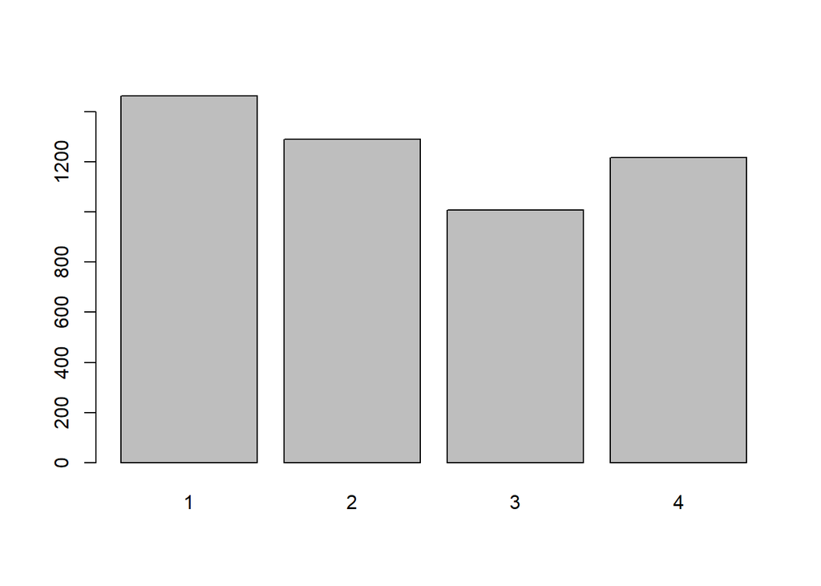

```r
barplot(table(bankData$Family_members))
```

```r
summary(bankData$CCAvg)
```

```
##    Min. 1st Qu.  Median    Mean 3rd Qu.    Max.
##   0.000   0.700   1.500   1.938   2.500  10.000
```

```r
summary(bankData$Education)
```

```
##    1    2    3
## 2096 1403 1501
```

```r
summary(bankData$Mortgage)
```

```
##    Min. 1st Qu.  Median    Mean 3rd Qu.    Max.
##     0.0     0.0     0.0    56.5   101.0   635.0
```

```r
typeof(bankData$Mortgage)
```

```
## [1] "double"
```

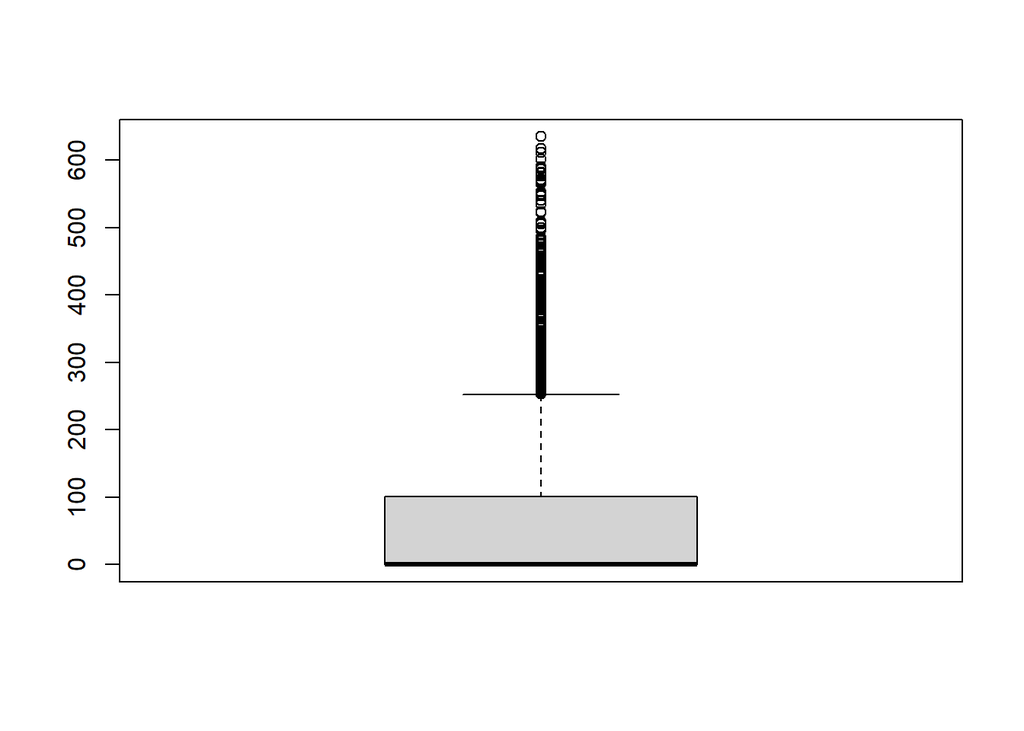

```r
boxplot(bankData$Mortgage)     #it has outliers
```

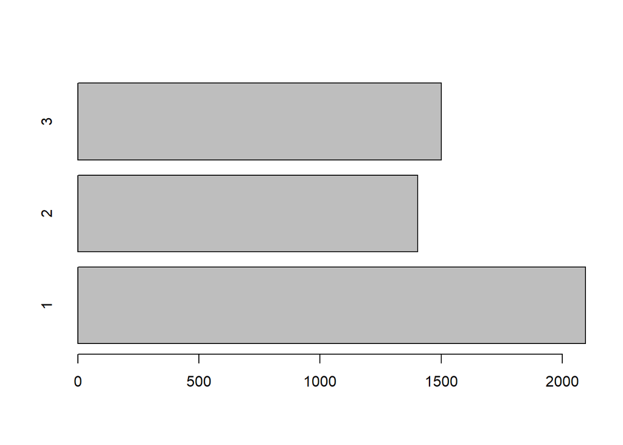

```r
barplot(table(bankData$Education),horiz = TRUE)
```

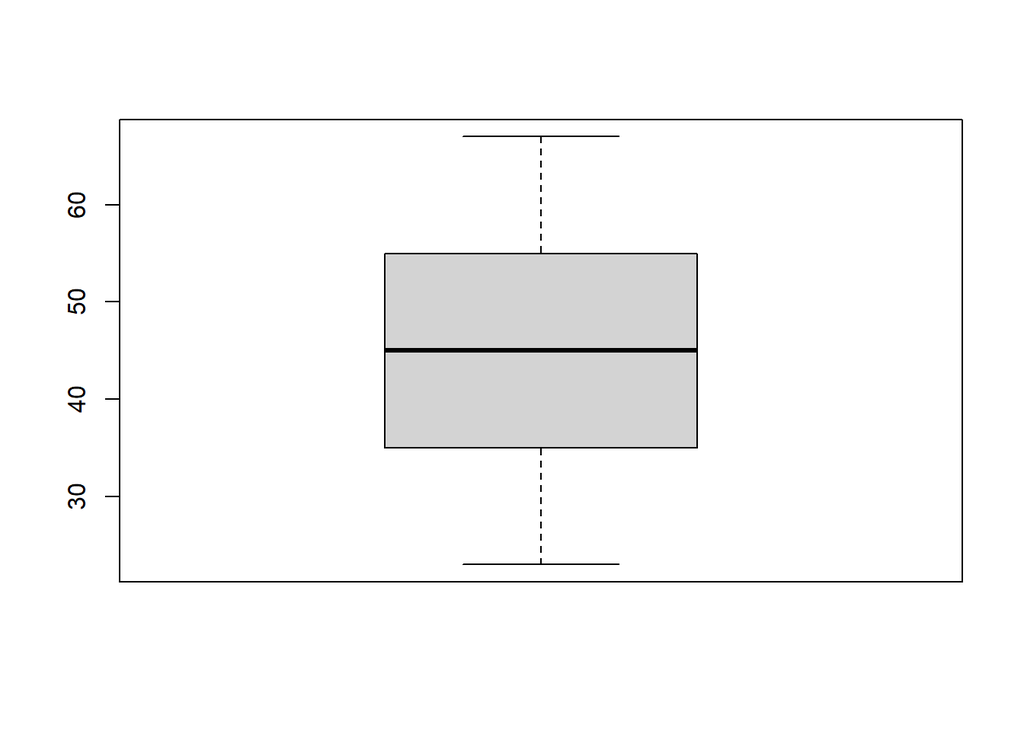

```r
boxplot(bankData$`Age_(in_years)`)
```

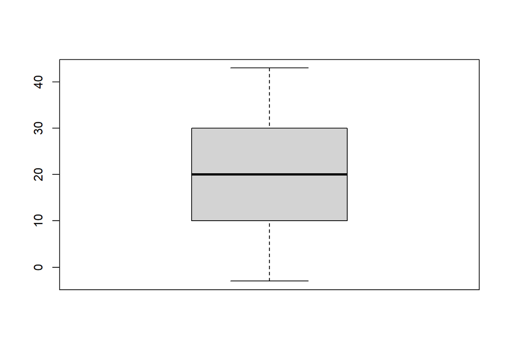

```r
boxplot(bankData$`Experience_(in_years)`)
```

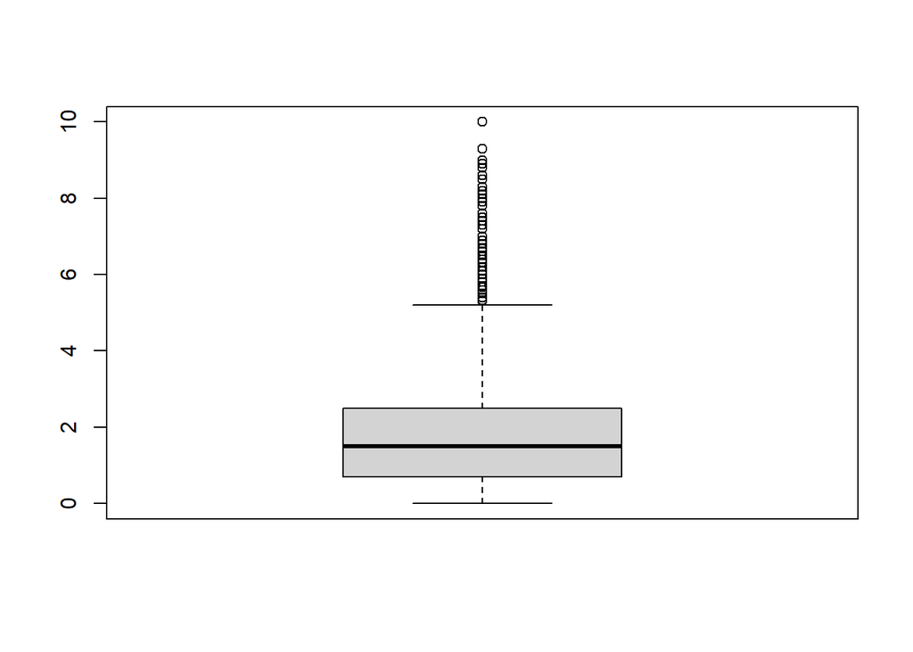

```r
#boxplot(bankData$`Income_(in_K/month)`)  #outliers
boxplot((bankData$CCAvg)) # There are many outliers , they can take loans.
```

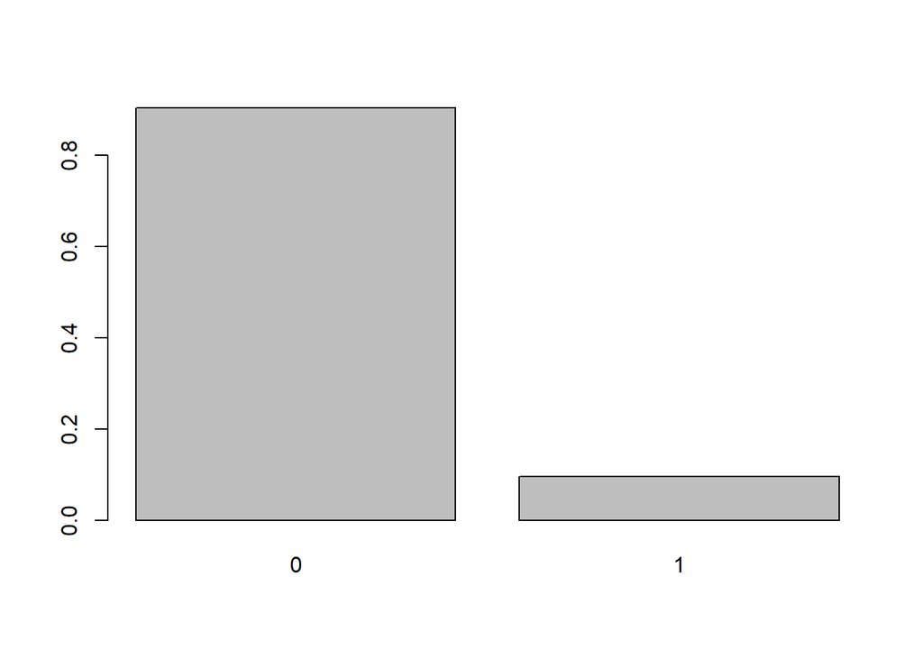

```r
barplot(prop.table(table(bankData$Personal_Loan)))
```

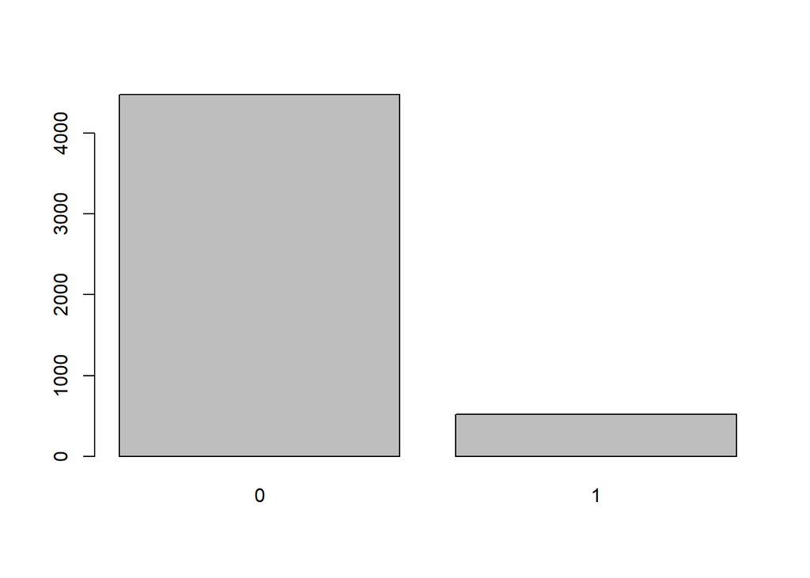

```r
barplot(table(bankData$Securities_Account))  #very less % has security acc
```

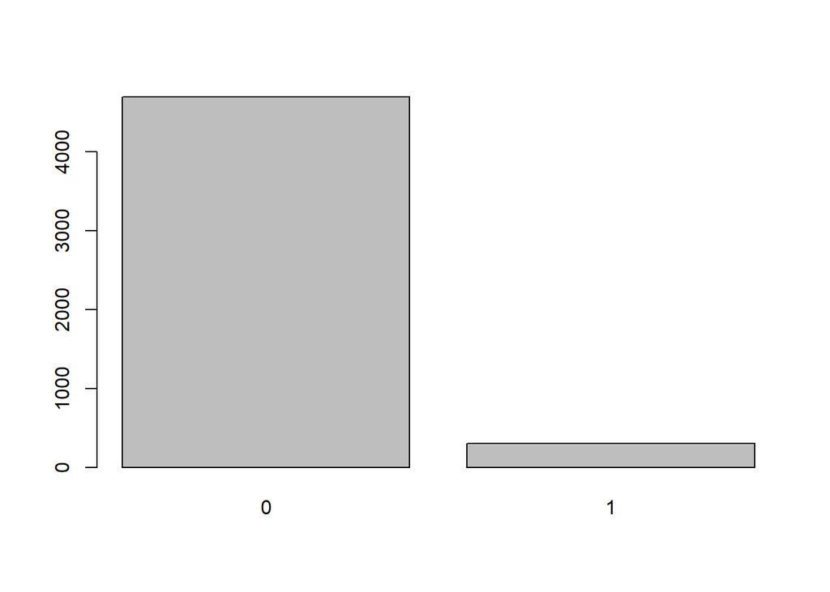

```r
barplot(table(bankData$CD_Account))
```

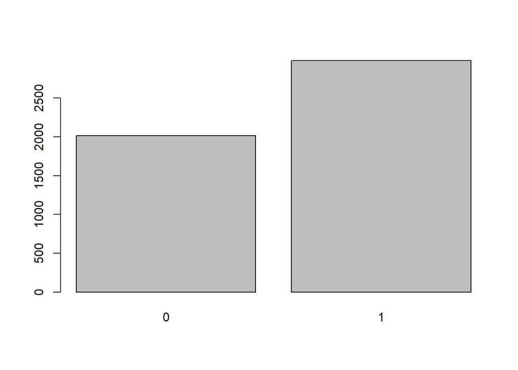

```r
barplot(table(bankData$Online))   # many ppl use internet banking
```

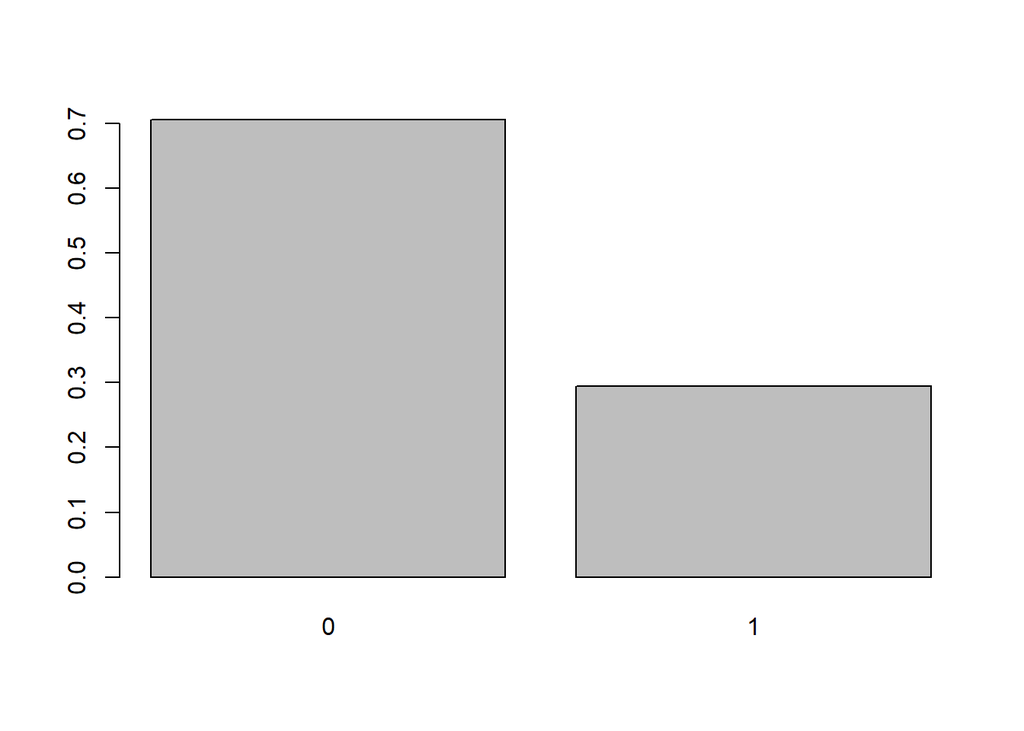

```r
barplot(prop.table(table(bankData$CreditCard)))
```

```r
prop.table(table(bankData$CreditCard)) #70% ppl dont have credit card.
```

```
##
##     0     1
## 0.706 0.294
```

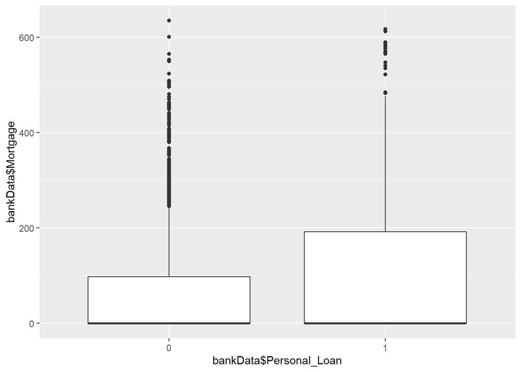

```r
#Bivariate EDA

library(ggplot2)
ggplot(bankData , aes(x= bankData$Personal_Loan,y=bankData$Mortgage))+
  geom_boxplot()
```

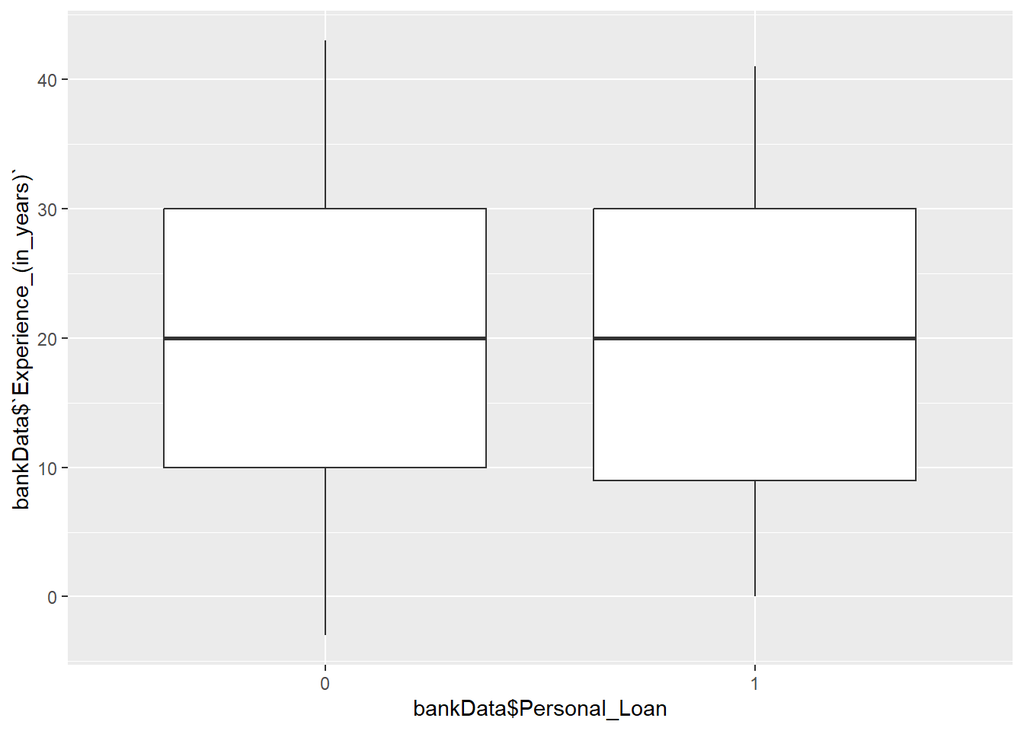

```r
ggplot(bankData , aes(x= bankData$Personal_Loan,y=bankData$`Experience_(in_years)`))+
  geom_boxplot()     #Prof Experience doesnt matter for personal loan
```

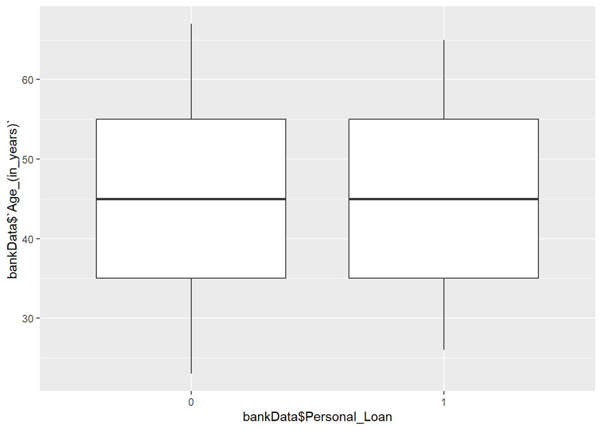

```r
ggplot(bankData , aes(x= bankData$Personal_Loan,y=bankData$`Age_(in_years)`))+
  geom_boxplot()     #Age doesnt matter for personal loan
```

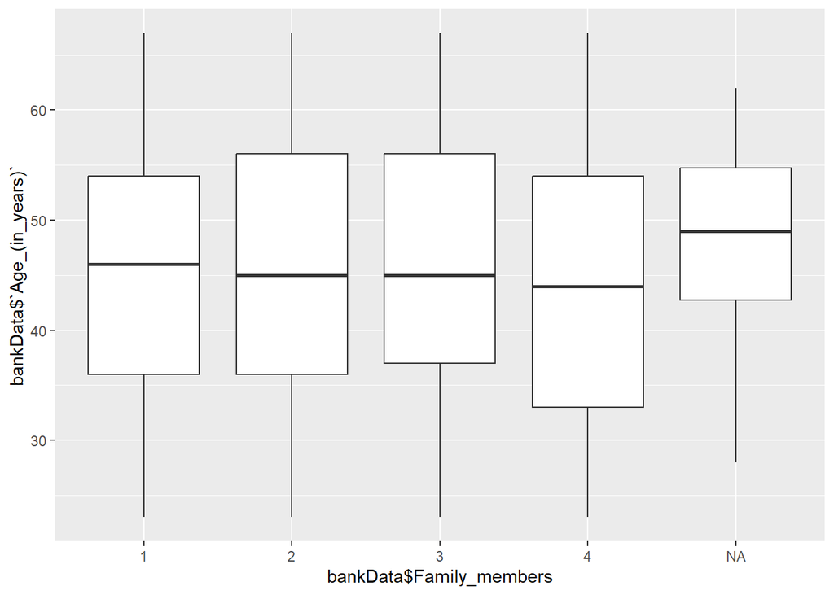

```r
ggplot(bankData,aes(y=bankData$`Age_(in_years)`,x=bankData$Family_members))+
  geom_boxplot()
```

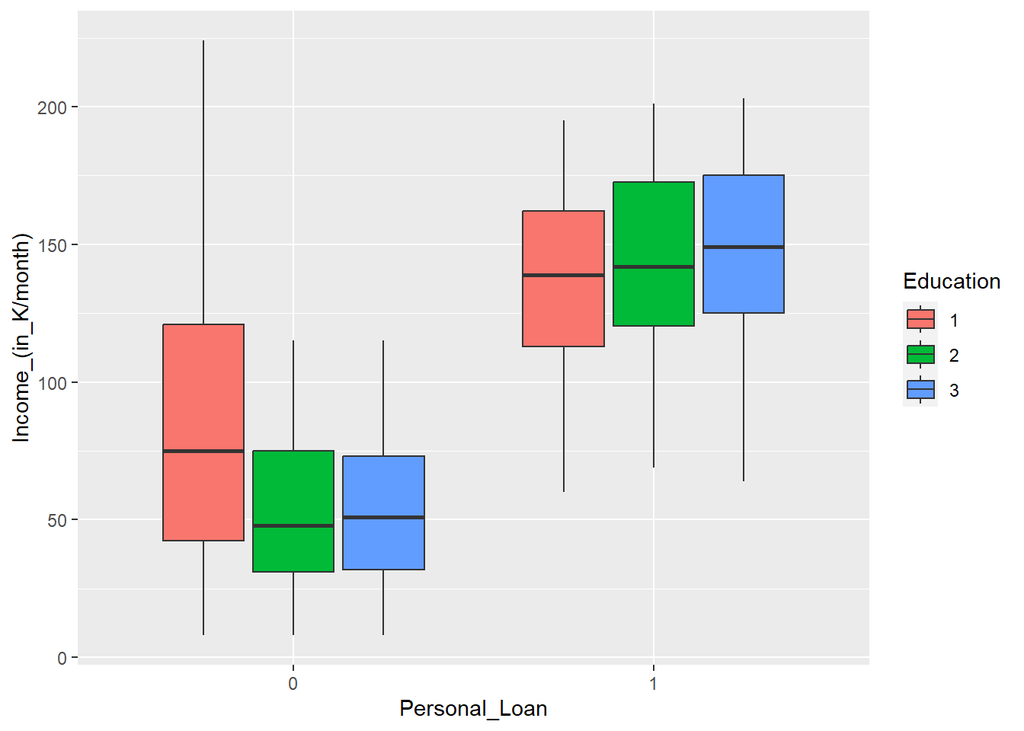

```r
#Target Variable : Personal_Loan
attach(bankData)
ggplot(bankData,aes(x=Personal_Loan,y=`Income_(in_K/month)`))+
  geom_boxplot(aes(fill=Education))
```

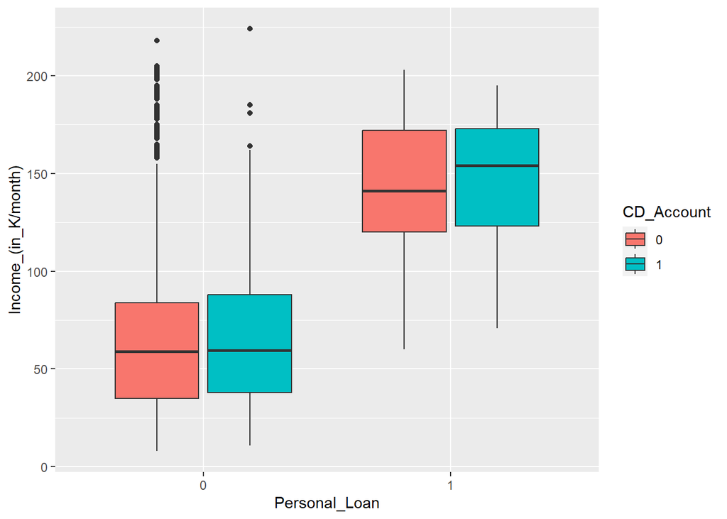

```r
ggplot(bankData,aes(x=Personal_Loan,y=`Income_(in_K/month)`))+
  geom_boxplot(aes(fill= CD_Account))
```

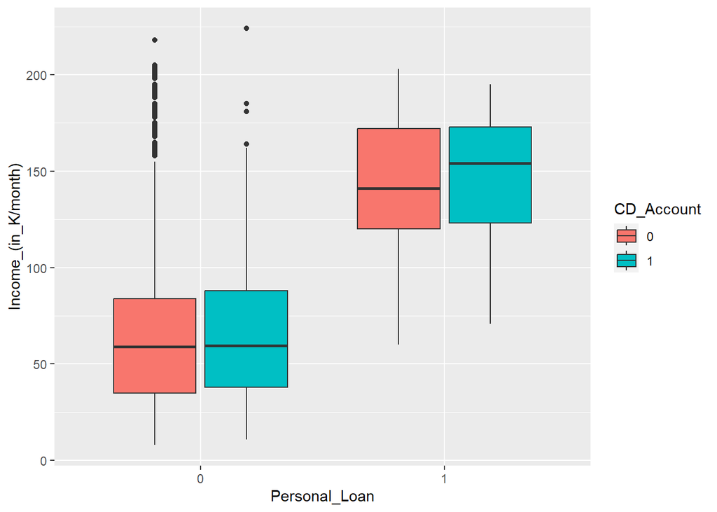

```r
ggplot(bankData,aes(x=Personal_Loan,y=`Income_(in_K/month)`))+
  geom_boxplot(aes(fill= CD_Account))
```

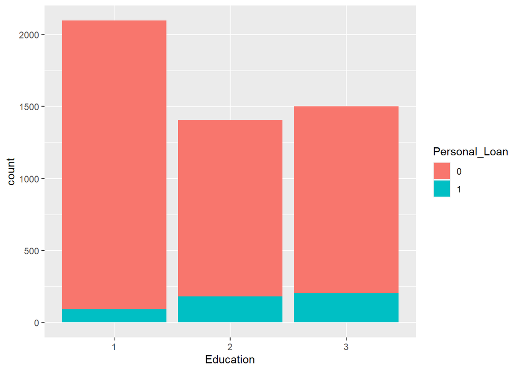

```r
library(ggplot2)
ggplot(bankData,aes(x=Education,fill=Personal_Loan))+
  geom_bar()
```

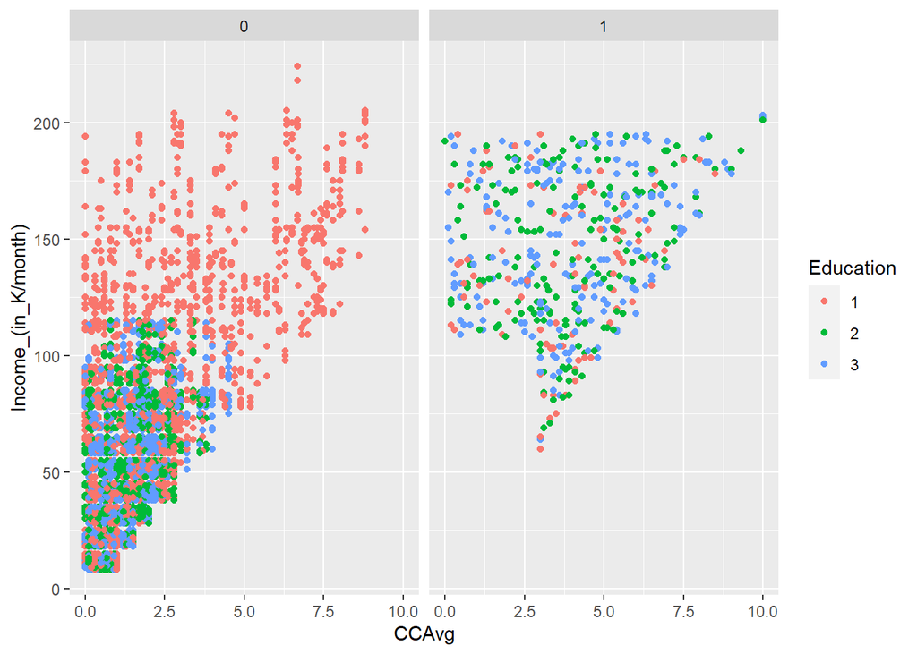

```r
library(ggplot2)
ggplot(bankData,aes(x=CCAvg,y=`Income_(in_K/month)`,col=Education))+
  geom_point()+
  facet_grid(.~Personal_Loan)
```

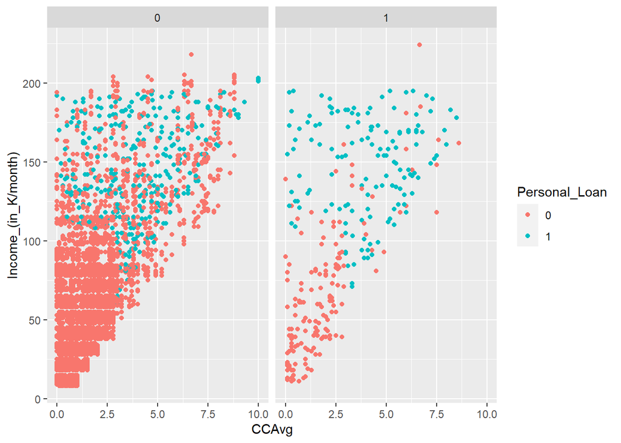

```r
ggplot(bankData,aes(x=CCAvg,y=`Income_(in_K/month)`,col=Personal_Loan))+
  geom_point()+
  facet_grid(.~CD_Account)
```

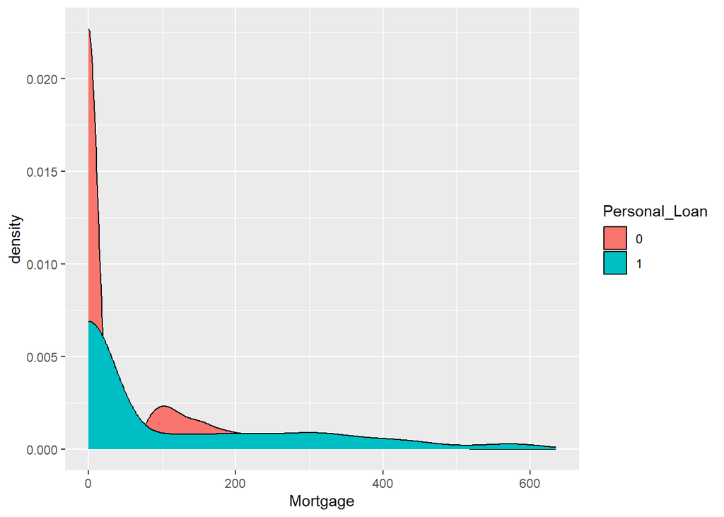

```r
ggplot(bankData,aes(x=Mortgage,fill=Personal_Loan))+
  geom_density()
```

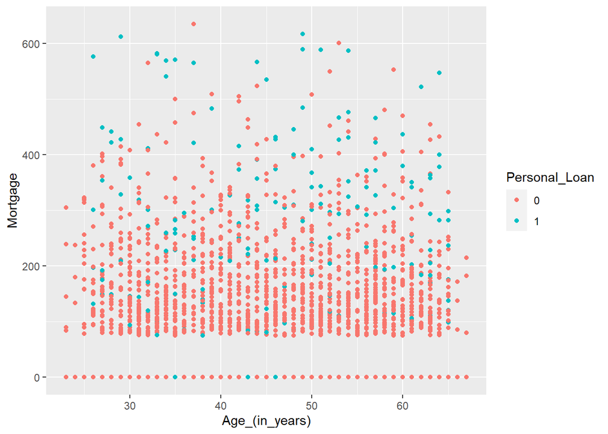

```r
ggplot(bankData,aes(x=`Age_(in_years)`,y=Mortgage,col=Personal_Loan))+
  geom_point()
```

```r
names(bankData)
```

```
##  [1] "ID"                    "Age_(in_years)"        "Experience_(in_years)"
##  [4] "Income_(in_K/month)"   "ZIP_Code"              "Family_members"
##  [7] "CCAvg"                 "Education"             "Mortgage"
## [10] "Personal_Loan"         "Securities_Account"    "CD_Account"
## [13] "Online"                "CreditCard"
```

```r
#Data Cleaning
"
1.Experience in years : has negative values.
2.Missing values in FamilyMembers.
3.Remove Unnecessary variables which cant help us in prediction like 'Id'
4.Income_(in_K_per_month has outliers.
5.average spending on credit card has many outliers:CCAvg

"
```

```
## [1] "\n1.Experience in years : has negative values.\n2.Missing values in FamilyMembers.\n3.Remove Unnecessary variables which cant help us in prediction like 'Id'\n4.Income_(in_K_per_month has outliers.\n5.average spending on credit card has many outliers:CCAvg\n\n"
```

```r
library(dplyr)
bankData %>%
  filter(is.na(bankData$Family_members))
```

| ID | Age_(in_years) | Experience_(in_years) | Income_(in_K/month) | ZIP_Code | Family_members | CCAvg | Education | Mortgage | Personal_Loan | Securities_Account | CD_Account | Online | CreditCard |
| --- | --- | --- | --- | --- | --- | --- | --- | --- | --- | --- | --- | --- | --- |
| 21 | 56 | 31 | 25 | 94015 | NA | 0.9 | 2 | 111 | 0 | 0 | 0 | 1 | 0 |
| 59 | 28 | 2 | 93 | 94065 | NA | 0.2 | 1 | 0 | 0 | 0 | 0 | 0 | 0 |
| 99 | 49 | 23 | 94 | 92374 | NA | 0.3 | 1 | 0 | 0 | 0 | 0 | 1 | 0 |
| 162 | 61 | 35 | 80 | 95053 | NA | 2.8 | 1 | 0 | 0 | 0 | 0 | 1 | 0 |
| 236 | 38 | 8 | 71 | 94720 | NA | 1.8 | 3 | 0 | 0 | 0 | 0 | 1 | 0 |
| 290 | 42 | 15 | 24 | 92121 | NA | 1.0 | 2 | 0 | 0 | 0 | 0 | 1 | 1 |
| 488 | 39 | 13 | 88 | 94117 | NA | 1.4 | 2 | 0 | 0 | 0 | 0 | 1 | 1 |
| 722 | 49 | 24 | 39 | 92717 | NA | 1.4 | 3 | 0 | 0 | 0 | 0 | 1 | 0 |
| 1461 | 40 | 16 | 85 | 92677 | NA | 0.2 | 3 | 0 | 0 | 0 | 0 | 1 | 1 |
| 1462 | 54 | 28 | 48 | 93022 | NA | 0.2 | 1 | 0 | 0 | 0 | 0 | 1 | 0 |

[output cut: 8 more lines]

```r
bankData %>%
  filter(bankData$`Experience_(in_years)`<0)
```

| ID | Age_(in_years) | Experience_(in_years) | Income_(in_K/month) | ZIP_Code | Family_members | CCAvg | Education | Mortgage | Personal_Loan | Securities_Account | CD_Account | Online | CreditCard |
| --- | --- | --- | --- | --- | --- | --- | --- | --- | --- | --- | --- | --- | --- |
| 90 | 25 | -1 | 113 | 94303 | 4 | 2.30 | 3 | 0 | 0 | 0 | 0 | 0 | 1 |
| 227 | 24 | -1 | 39 | 94085 | 2 | 1.70 | 2 | 0 | 0 | 0 | 0 | 0 | 0 |
| 316 | 24 | -2 | 51 | 90630 | 3 | 0.30 | 3 | 0 | 0 | 0 | 0 | 1 | 0 |
| 452 | 28 | -2 | 48 | 94132 | 2 | 1.75 | 3 | 89 | 0 | 0 | 0 | 1 | 0 |
| 525 | 24 | -1 | 75 | 93014 | 4 | 0.20 | 1 | 0 | 0 | 0 | 0 | 1 | 0 |
| 537 | 25 | -1 | 43 | 92173 | 3 | 2.40 | 2 | 176 | 0 | 0 | 0 | 1 | 0 |
| 541 | 25 | -1 | 109 | 94010 | 4 | 2.30 | 3 | 314 | 0 | 0 | 0 | 1 | 0 |
| 577 | 25 | -1 | 48 | 92870 | 3 | 0.30 | 3 | 0 | 0 | 0 | 0 | 0 | 1 |
| 584 | 24 | -1 | 38 | 95045 | 2 | 1.70 | 2 | 0 | 0 | 0 | 0 | 1 | 0 |
| 598 | 24 | -2 | 125 | 92835 | 2 | 7.20 | 1 | 0 | 0 | 1 | 0 | 0 | 1 |

[output cut: 42 more lines]

```r
#Conclude: There are 52 rows where experience is negative : Exp cant be negative # so we will mutate as abs value of exp : considering it to be typing err

bankData$`Experience_(in_years)`=abs(bankData$`Experience_(in_years)`)
bankData<-bankData[,-c(1,5)]
```

```r
"
For Missing values in FamilyMembers.lets build a model to predict the family members for given data"
```

```
## [1] "\nFor Missing values in FamilyMembers.lets build a model to predict the family members for given data"
```

```r
#"For now , just mutate it as 1 : considering they are single person"
bankData[is.na(bankData$Family_members),"Family_members"] <- factor(1)

#check if missing value got replaced.
colSums(is.na(bankData))
```

```
##        Age_(in_years) Experience_(in_years)   Income_(in_K/month)
##                     0                     0                     0
##        Family_members                 CCAvg             Education
##                     0                     0                     0
##              Mortgage         Personal_Loan    Securities_Account
##                     0                     0                     0
##            CD_Account                Online            CreditCard
##                     0                     0                     0
```

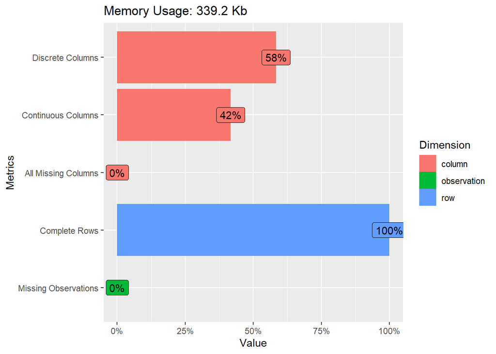

```r
library(DataExplorer)
plot_intro(bankData)
```

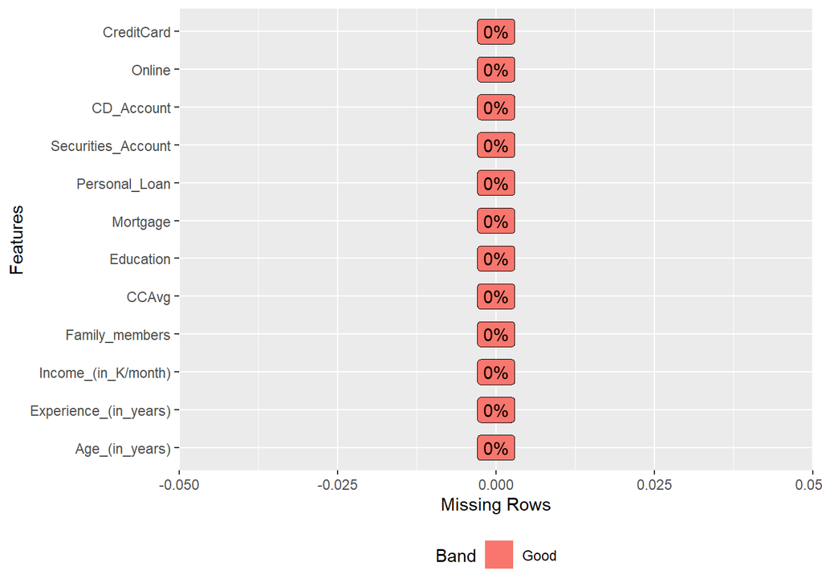

```r
plot_missing(bankData)
```

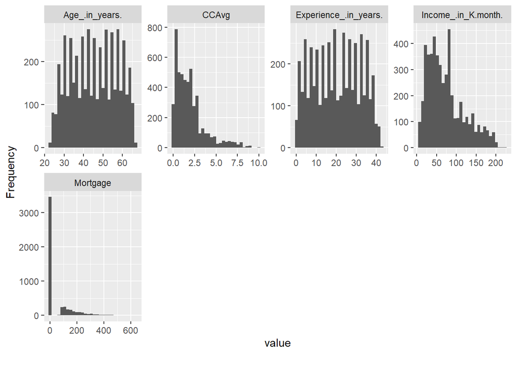

```r
plot_histogram(bankData)
```

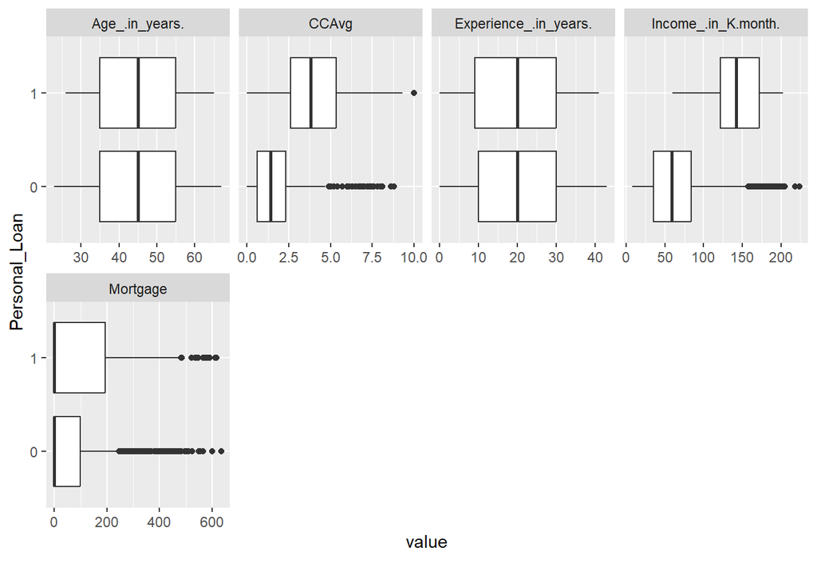

```r
plot_boxplot(bankData,by="Personal_Loan")
```

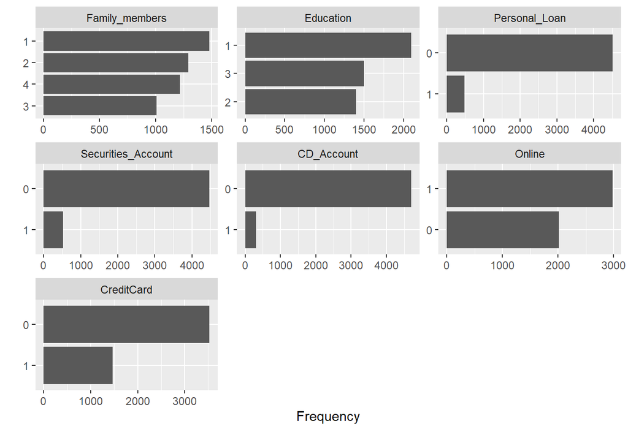

```r
plot_bar(bankData)
```

#Splitting the data into test and traindata

```r
library(caTools)

set.seed(127)

split=sample.split(bankData$Personal_Loan ,SplitRatio = 0.7)
head(bankData)
```

| Age_(in_years) | Experience_(in_years) | Income_(in_K/month) | Family_members | CCAvg | Education | Mortgage | Personal_Loan | Securities_Account | CD_Account | Online | CreditCard |
| --- | --- | --- | --- | --- | --- | --- | --- | --- | --- | --- | --- |
| 25 | 1 | 49 | 4 | 1.6 | 1 | 0 | 0 | 1 | 0 | 0 | 0 |
| 45 | 19 | 34 | 3 | 1.5 | 1 | 0 | 0 | 1 | 0 | 0 | 0 |
| 39 | 15 | 11 | 1 | 1.0 | 1 | 0 | 0 | 0 | 0 | 0 | 0 |
| 35 | 9 | 100 | 1 | 2.7 | 2 | 0 | 0 | 0 | 0 | 0 | 0 |
| 35 | 8 | 45 | 4 | 1.0 | 2 | 0 | 0 | 0 | 0 | 0 | 1 |
| 37 | 13 | 29 | 4 | 0.4 | 2 | 155 | 0 | 0 | 0 | 1 | 0 |

```r
trData<-subset(bankData,split==TRUE)
tstData<-subset(bankData,split==FALSE)

dim(trData)
```

```
## [1] 3500   12
```

```r
dim(tstData)
```

```
## [1] 1500   12
```

```r
#Check if the proportions of levels of PersonalLoan is same in test and train data to avoid baising
prop.table(table(trData$Personal_Loan))
```

```
##
##     0     1
## 0.904 0.096
```

```r
prop.table(table(tstData$Personal_Loan))
```

```
##
##     0     1
## 0.904 0.096
```

#Step1 : First Cart Model without any control parameters : it self pruned it to the max level

```r
library(rpart)
library(rpart.plot)
tree<-rpart(formula = Personal_Loan ~ .,data = trData)
printcp(tree)
```

```
##
## Classification tree:
## rpart(formula = Personal_Loan ~ ., data = trData)
##
## Variables actually used in tree construction:
## [1] Age_(in_years)      CCAvg               CD_Account
## [4] Education           Family_members      Income_(in_K/month)
##
## Root node error: 336/3500 = 0.096
##
## n= 3500
##
##         CP nsplit rel error  xerror     xstd
## 1 0.328869      0   1.00000 1.00000 0.051870
## 2 0.145833      2   0.34226 0.37500 0.032801
## 3 0.016369      3   0.19643 0.23214 0.025990
## 4 0.010417      5   0.16369 0.19940 0.024127
## 5 0.010000      8   0.12798 0.19048 0.023591
```

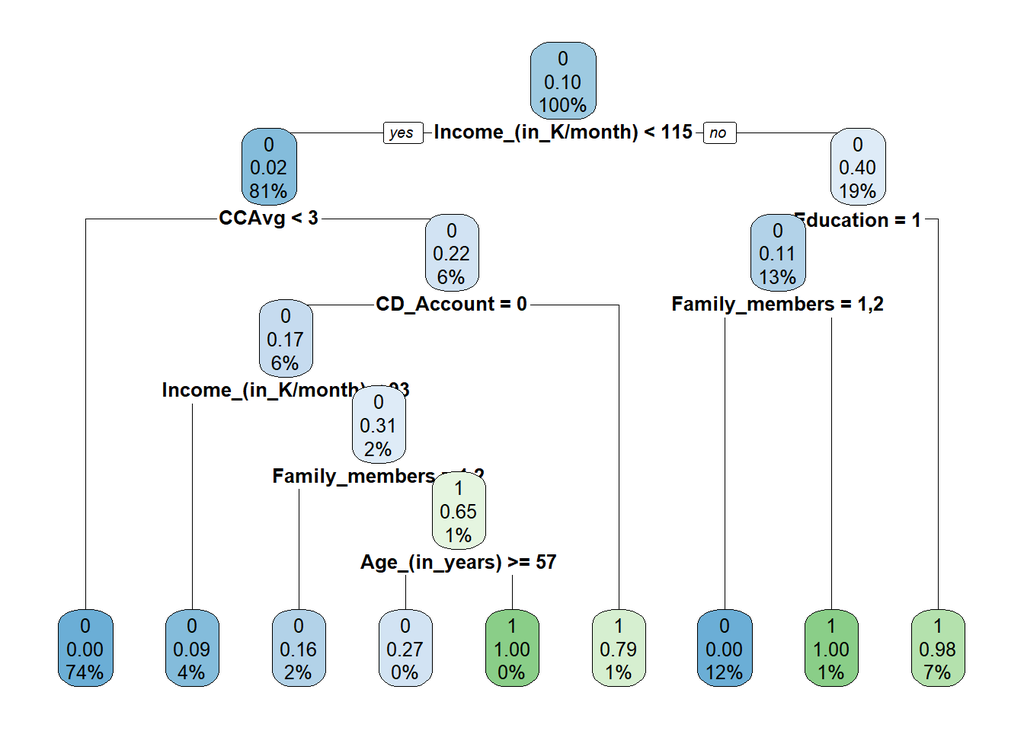

```r
rpart.plot(tree,cex=0.8)
```

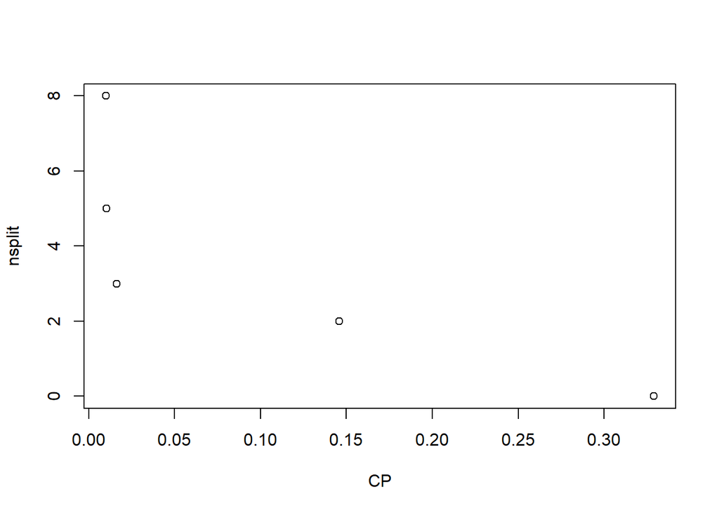

```r
plot(tree$cptable)
```

#To get granular details of tree : built tree with control parameters

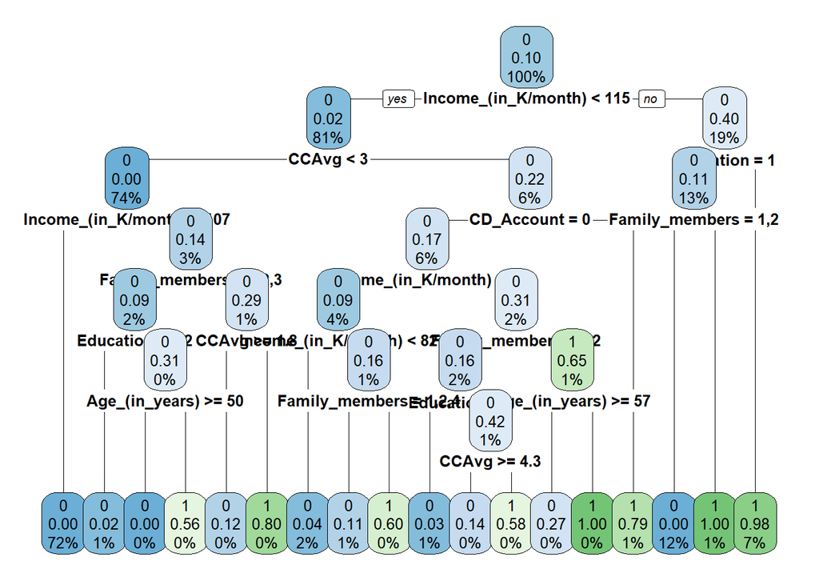

```r
#Initial Tree build
library(rpart)
library(rpart.plot)
set.seed(127)
trData$predicted.class=NULL
trData$predicted.score=NULL

tree<-rpart(formula = Personal_Loan ~ .,data = trData, control = rpart.control(minbucket = 5, cp = .000001))
rpart.plot(tree,cex=0.8)
```

#Finding the bestcp to prune the tree

```r
print(tree$cptable)
```

```
##            CP nsplit rel error    xerror       xstd
## 1 0.328869048      0 1.0000000 1.0000000 0.05186980
## 2 0.145833333      2 0.3422619 0.3720238 0.03267523
## 3 0.016369048      3 0.1964286 0.2142857 0.02499271
## 4 0.010416667      5 0.1636905 0.1904762 0.02359083
## 5 0.002976190      8 0.1279762 0.1636905 0.02189791
## 6 0.001488095     13 0.1130952 0.1845238 0.02322606
## 7 0.000001000     17 0.1071429 0.1904762 0.02359083
```

```r
bestcp<-tree$cptable[which.min(tree$cptable[,"xerror"]),"CP"]
bestcp
```

```
## [1] 0.00297619
```

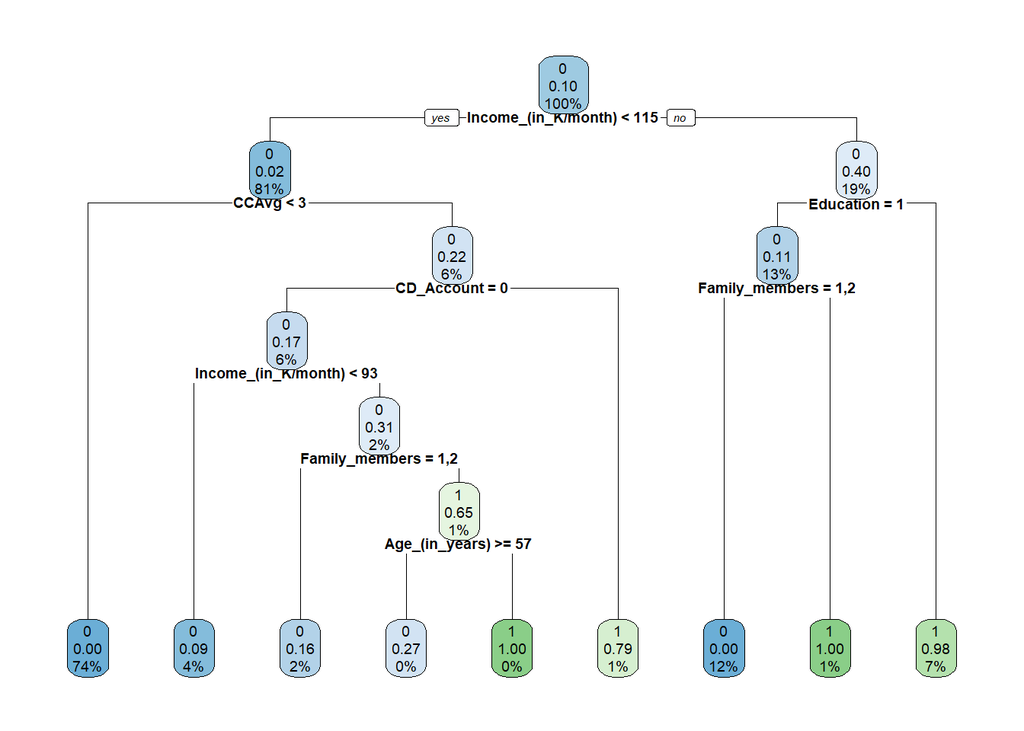

```r
#pruning the tree
prunedTree<-prune(tree,cp=0.00298)
rpart.plot(prunedTree,cex=0.6)
```

#Understanding Variable Importance

```r
prunedTree$variable.importance
```

```
##             Education   Income_(in_K/month)        Family_members
##            237.139737            166.956935            160.140394
##                 CCAvg            CD_Account              Mortgage
##             81.631983             57.959573             20.506291
##        Age_(in_years) Experience_(in_years)                Online
##              9.209210              8.175319              2.759612
```